# Models lineals generalitzats

Antonio Miñarro (aminarro@ub.edu)

05 octubre, 2023

# 1 Models Lineals Generalitzats

- La majoria de les anàlisis que hem presentat demanen normalitat de la variable resposta i residus del model.
- Es cert que els models lineals són fins un cert punt robusts front a desviacions moderades de la normalitat.
- Algunes transformacions de les variables poden arreglar aquestes desviacions i recuperar normalitat.
- Hi ha situacions on la transformació de les variables no funciona per normalitzar els errors (e.g. si la variable resposta és categòrica).
- Si és possible, sempre és millor modelitzar la veritable distribució de la variable resposta.

## 1.1 Exemple 1

- Pine et al (1983) estudien malalts amb sèpsia abdominal severa que requereix cirurgia per evitar la mort.
- El resultat de la cirurgia (supervivència o mort) pot estar correlacionats amb l’edat i altres possibles condicions dels pacients.
- A l’estudi inclourem com a variable resposta la situació de supervivència (Y) (0=Sobreviu, 1=Mor),
- Tenim cinc variables potencialment predictores, de les quals 4 són binàries i una és continua
  - $X_1:$ Xoc (0/1)
  - $X_2:$ Malnutrició (0/1)
  - $X_3:$ Alcoholisme (0/1)
  - $X_4:$ Edat
  - $X_5:$ Infart intestinal (0/1)

## 1.2 Models lineals generalitzats (GLM)

- Els GLMs estenen els models lineals a una gama més amplia de variables resposta.

  -Variables amb un rang restringit: resposta binaria, comptatges, scores,..

  -Variància de la variable resposta dependent de la esperança.
- Alguns GLM’s reben noms específics:

  -Regressió logística

  -Regressió ordinal

  -Regressió de Poisson

## 1.3 Models lineals generalitzats (2)

- Aquestes generalitzacions amplien considerablement l’aplicabilitat del marc dels models lineals, permetent un procediment d’ajust i interpretació semblant dels models resultants.
- Als GLM es calculen els coeficients iterativament per maximització numèrica de l’estimació de màxima versemblança en comptes de les tècniques de mínims quadrats ordinaris. La utilització de tècniques numèriques pot provocar problemes (no convergència) en l’obtenció de solucions.
- Als GLM el concepte de suma de quadrats ve substituït pel de deviància. Per distribucions normals, la deviància i la suma de quadrats són equivalents.

## 1.4 Exemple 1: Relació de la presència de xoc amb la mort

- Pine et al (1983) estudien malalts amb sèpsia abdominal severa que requereix cirurgia per evitar la mort.
- El resultat de la cirurgia (supervivència o mort) pot estar correlacionats amb l’edat i altres possibles condicions dels pacients.
- A l’estudi inclourem com a variable resposta la situació de supervivència (Y) (0=Sobreviu, 1=Mor),
- Tenim cinc variables potencialment predictores, de les quals 4 són binàries i una és continua
  - $X_1:$ Xoc (0/1)
  - $X_2:$ Malnutrició (0/1)
  - $X_3:$ Alcoholisme (0/1)
  - $X_4:$ Edat
  - $X_5:$ Infart intestinal (0/1)
- Les dades es troben al fitxer **dades/Exemple_6.1.csv**

```r
ex1DataPine<-read.table('../dades/Exemple_6.1.csv',header=T,sep=';',dec=',',stringsAsFactors = T)
head(ex1DataPine)
```

| ID | Y | X1 | X2 | X3 | X4 | X5 |
| --- | --- | --- | --- | --- | --- | --- |
| 1 | 0 | 0 | 0 | 0 | 56 | 0 |
| 2 | 0 | 0 | 0 | 0 | 80 | 0 |
| 3 | 0 | 0 | 0 | 0 | 61 | 0 |
| 4 | 0 | 0 | 0 | 0 | 26 | 0 |
| 5 | 0 | 0 | 0 | 0 | 53 | 0 |
| 6 | 1 | 0 | 1 | 0 | 87 | 0 |

Considerem la relació entre la mort i la presència de xoc

```r
table(ex1DataPine$X1,ex1DataPine$Y,dnn=c('Xoc','Mort'))
```

```
##    Mort
## Xoc  0  1
##   0 82 14
##   1  3  7
```

La probabilitat de mort si hi ha Xoc és 7/10 = 0,7

La probabilitat de mort si no hi ha Xoc és 14/96 = 0,1458

L’**odds ratio** associat amb el Xoc és 7·82 / 14·3 = 13,7

Com recordaràs de primer, l’**odds ratio** indica que la fracció d’individus que moren respecte als que no és 13,7 vegades superior en els individus que han patit un xoc.

La verificació de que hi ha relació la podem fer amb una prova khi-quadrat

```r
chisq.test(ex1DataPine$Y,ex1DataPine$X1)
```

```
##
##  Pearson's Chi-squared test with Yates' continuity correction
##
## data:  ex1DataPine$Y and ex1DataPine$X1
## X-squared = 14.193, df = 1, p-value = 0.000165
```

## 1.5 Exemple 1: Relació de la presència de xoc amb la mort (2)

El nostre primer objectiu seria trobar una expressió que ens donés el resultat de l’experiment (mort o no mort) segons el Xoc estigués present o absent. Considerem que la variable resposta Y segueix una distribució Bernouilli de paràmetre p i que, una alternativa és el següent model lineal

$$y_i=\beta_0+\beta_1 x_{i1}+\epsilon_i
\,\,\,\, \mbox{ amb } E(\epsilon_i)=0$$
Llavors

$$E(y_i)=p_i=\beta_0+\beta_1
x_{i1}$$

Aquesta formulació directa no acaba de funcionar degut a les propietats de la distribució: la resposta estaria acotada per (0,1), el terme d’error seria binari, la variància de les observacions és funció de la mitjana, etc.

## 1.6 Exemple 1: Regressió logística, logit link

El model lineal generalitzat per a una variable resposta binomial (regressió logística) busca una funció (**funció link**) que converteixi la predicció de la funció lineal dels predictors en una probabilitat. Aquesta funció, en el cas de la regressió logística és la funció

$$g(p_i) = logit(p_i) = \log
\frac{p_i}{1-p_i}=\beta_0+\beta_1 x_{i1}$$

Aquesta funció rep el nom de funció d’enllaç logit (logit link). La unitat de mesura en l’escala transformada s’anomena **logit** (de **log**istic un**it**)

Amb la funció inversa és fàcil obtenir l’expressió per la probabilitat $p_i$

$$p_i = \frac{e^{\beta_0+\beta_1
x_{i1}}}{1+e^{\beta_0+\beta_1 x_{i1}}}=\frac{1}{1+e^{-(\beta_0+\beta_1
x_{i1})}}$$

La gràfica de la funció logit és la següent

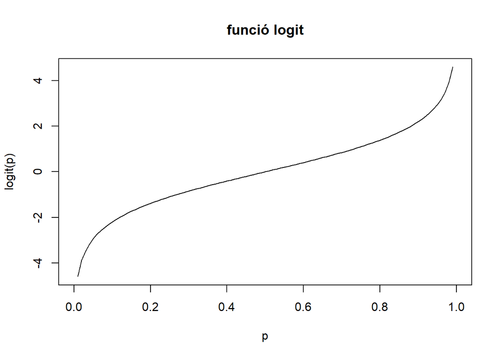

i la seva inversa

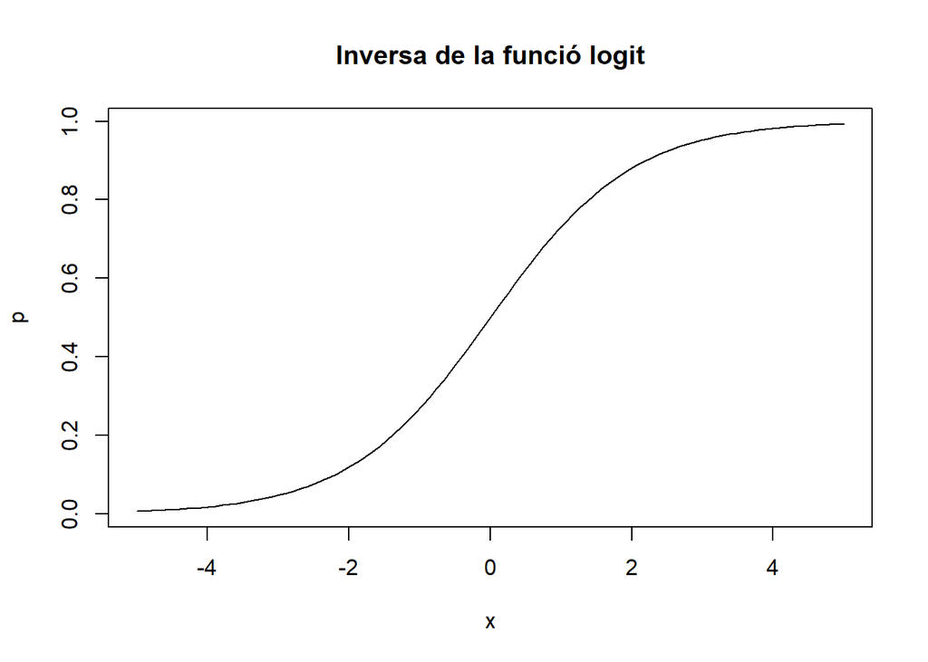

### 1.6.1 Propietats

1. $logit(p) \in (-\infty,\infty$)
2. $p \rightarrow 1 \Rightarrow logit(p) = +\infty$
3. $p \rightarrow 0 \Rightarrow logit(p) = -\infty$
4. $logit(0.5)=0$
5. $logit(p)=z \Rightarrow p = \frac{e^z}{1+e^z} = \frac{1}{1+e^{-z}}$

## 1.7 Model per a un GLM

- Variable resposta: Y amb distribució coneguda però no necessàriament normal.
- Component sistemàtica, predictors lineals

$$\eta_i = \beta_0 + \beta_1 \cdot x_{1i}
+ \cdots + \beta_1 \cdot x_{ki}$$

- Funció d’enllaç (**link** ) que descriu cóm la esperança de la variable resposta $E(Y_i)=\mu_i$ està relacionada amb els predictors

$$g(\mu_i) = \eta_i = \beta_0 + \beta_1
\cdot x_{i1} + \cdots + \beta_1 \cdot x_{ik}$$

## 1.8 Altres funcions d’enllaç (link functions)

- **Link identitat**: $g(\mu) = \mu$. És el que s’utilitza en un model lineal general.
- **Link log**: $g(\mu) = \log(\mu)$ . Utilitzat en dades de comptatge, valors positius, en regressió de Poisson i models log-lineals.
- **Link logit**: $g(\mu) = \log(\mu/(1-\mu))$. Utilitzat per dades binàries en regressió logística.

## 1.9 Estimació de paràmetres

- L’estimació dels paràmetres $\alpha, \beta_1$ es fa pel mètode de la màxima versemblança i generalment les equacions requereixen algorismes iteratius per la seva resolució.
- La majoria de paquets estadístics, com **R**, porten incorporats els algorismes que permeten ajustar els paràmetres del model.

## 1.10 Exemple 1: Estructura de les dades i ajust del model

Recordem l’estructura de les dades al nostre exemple:

```r
head(ex1DataPine)
```

| ID | Y | X1 | X2 | X3 | X4 | X5 |
| --- | --- | --- | --- | --- | --- | --- |
| 1 | 0 | 0 | 0 | 0 | 56 | 0 |
| 2 | 0 | 0 | 0 | 0 | 80 | 0 |
| 3 | 0 | 0 | 0 | 0 | 61 | 0 |
| 4 | 0 | 0 | 0 | 0 | 26 | 0 |
| 5 | 0 | 0 | 0 | 0 | 53 | 0 |
| 6 | 1 | 0 | 1 | 0 | 87 | 0 |

L’ajust d’un model lineal generalitzat a R el podem fer amb la funció **glm**.

> glm(resposta~X1+X2+….,family=’binomial(),…)

El paràmetre *family* especifica el link que es vol utilizar i que depèn del tipus de variable resposta.

- binomial(link = ‘logit’)
- gaussian(link = ‘identity’)
- poisson(link = ‘log’)
- quasipoisson(link = ‘log’)

### 1.10.1 Ajust del model per xoc

```r
pine_1<-glm(Y~X1,data=ex1DataPine,family=binomial())
summary(pine_1)
```

```
##
## Call:
## glm(formula = Y ~ X1, family = binomial(), data = ex1DataPine)
##
## Coefficients:
##             Estimate Std. Error z value Pr(>|z|)
## (Intercept)  -1.7677     0.2892  -6.113 9.79e-10 ***
## X1            2.6150     0.7482   3.495 0.000474 ***
## ---
## Signif. codes:  0 '***' 0.001 '**' 0.01 '*' 0.05 '.' 0.1 ' ' 1
##
## (Dispersion parameter for binomial family taken to be 1)
##
##     Null deviance: 105.528  on 105  degrees of freedom
## Residual deviance:  91.977  on 104  degrees of freedom
## AIC: 95.977
##
## Number of Fisher Scoring iterations: 4
```

#### 1.10.1.1 Inferència sobre el model

El llistat ens presenta un test d’hipòtesis sobre els paràmetres del model i la *desviància* residual del model front la de un model sense la variable predictora.

Podem demanar intervals de confiança sobre els paràmetres

```r
confint(pine_1)
```

```
##                 2.5 %    97.5 %
## (Intercept) -2.377144 -1.234687
## X1           1.218475  4.242357
```

#### 1.10.1.2 Probabilitats estimades de mors sense xoc i amb xoc

$$X_1=0 \Rightarrow logit(p)= -1.7677
\Rightarrow p = \frac{e^{-1.7677}} {1+e^{-1.7677}} = 0.1458$$

$$X_1=1 \Rightarrow logit(p)= -1.7677 +
2.615 = 0.8473 \Rightarrow p = \frac{e^{0.8473}} {1+e^{0.8473}} = 0.7$$

## 1.11 Desviància

- La desviància es una mesura de l’ajust d’un model i avalua la discrepancia entre els valors predits i els valors observats. Mesura la quantitat de variabilitat que resta després d’ajustar el model.
- Si la variable resposta Y es normal, la desviància del model lineal és igual a la suma de quadrats dels residus.
- Si el nombre total de repliques es N i el model incorpora k variables predictores, la desviància té N-k-1 graus de llibertat
- Comparar la desviància del model amb la nul·la (igual probabilitat independentment de les variables predictores) ens pot donar una idea de la bondat del model, però és utilitzada més sovint per comparar diversos models.

```r
pine_null<-glm(Y~1,data=ex1DataPine,family=binomial())
anova(pine_null,pine_1,test='Chisq')
```

| Resid. Df | Resid. Dev | Df | Deviance | Pr(>Chi) |
| --- | --- | --- | --- | --- |
| 105 | 105.52843 | NA | NA | NA |
| 104 | 91.97658 | 1 | 13.55185 | 0.0002321 |

## 1.12 *Odds* i *odds ratio*

- Anomenem *odds* de x a $o(x) =\frac{p}{1-p}$. És el quocient entre la probabilitat de presentar la característica estudiada respecte a la de no presentar-la.
- És immediat que $o(x) \in (0,+\infty)$ i que $logit(p)=log(o(x)) \Rightarrow o(x) = e^{\beta_0+\beta_1 x_{i1}}=e^{\beta_0} \cdot e^{\beta_1 x_{i1}}$

En el nostre exemple

$$o(0) = e^{-1.7677} = 0.1707$$
i

$$o(1) = e^{-1.7677+2.615} = 2.3333$$
Són les proporcions d’individus morts respecte als no morts en individus amb xoc i sense

I si un individu passa de no tenir xoc a tenir-lo (incrementem la variable $X_1$ en una unitat) els seus *odds* s’incrementen per un factor

$$o(0) = e^\alpha$$
$$o(1) = e^{\alpha+\beta_1}=e^\alpha \cdot
e^{\beta_1}$$
$$o(1)=o(0) \cdot
e^{\beta_1} = o(0) \cdot e^{2.615} = o(0) \cdot 13.7$$
que són els *odds ratio* que hem vist al principi.

Podem construir un interval de confiança sobre els *odds ratio*

```r
exp(confint(pine_1,parm='X1'))
```

```
##     2.5 %    97.5 %
##  3.382026 69.571646
```

## 1.13 Prediccions amb glm

```r
head(predict(pine_1,type='response'),24)
```

```
##         1         2         3         4         5         6         7         8
## 0.1458333 0.1458333 0.1458333 0.1458333 0.1458333 0.1458333 0.1458333 0.1458333
##         9        10        11        12        13        14        15        16
## 0.1458333 0.1458333 0.1458333 0.1458333 0.1458333 0.1458333 0.1458333 0.1458333
##        17        18        19        20        21        22        23        24
## 0.1458333 0.1458333 0.7000000 0.1458333 0.1458333 0.1458333 0.7000000 0.7000000
```

## 1.14 Generalització a k predictors

Si disposem de $k$ variables predictores el model queda

$$g(p_i) = logit(p_i) = \log
\frac{p_i}{1-p_i}=\beta_0+\beta_1 x_{i1}+ \cdots + \beta_k x_{ik}$$

Els *odds ratio* es calculen per cada variable predictora $X_j$ i representen com es modifiquen els *odds* de l’esdeveniment quan la variable $X_j$ s’incrementa en una unitat i la resta de variables no es modifiquen.

Considerem j=1

$$o(x_1)=e^{\beta_0+\beta_1 x_{i1}+ \cdots
+ \beta_k x_{ik}}=e^\beta_0 \cdot e^{\beta_1 x_{i1}} \cdots e^{\beta_k
x_{ik}}$$

$$o(x_1 +1)=e^{\beta_0+\beta_1 (x_{i1}+1)
+ \cdots + \beta_k x_{ik}}=e^\beta_0 \cdot e^{\beta_1 x_{i1}} \cdot
e^{\beta_1} \cdots e^{\beta_k x_{ik}} = o(x_1) \cdot
e^{\beta_1}$$

$$\frac{o(x_1+1)}{o(x_1)}=e^{\beta_1}$$

## 1.15 Ajust del model amb els 5 predictors

```r
pine_5<-glm(Y~X1+X2+X3+X4+X5,data=ex1DataPine,family=binomial())
summary(pine_5)
```

```
##
## Call:
## glm(formula = Y ~ X1 + X2 + X3 + X4 + X5, family = binomial(),
##     data = ex1DataPine)
##
## Coefficients:
##             Estimate Std. Error z value Pr(>|z|)
## (Intercept) -9.75391    2.54170  -3.838 0.000124 ***
## X1           3.67387    1.16481   3.154 0.001610 **
## X2           1.21658    0.72822   1.671 0.094798 .
## X3           3.35488    0.98210   3.416 0.000635 ***
## X4           0.09215    0.03032   3.039 0.002374 **
## X5           2.79759    1.16397   2.403 0.016240 *
## ---
## Signif. codes:  0 '***' 0.001 '**' 0.01 '*' 0.05 '.' 0.1 ' ' 1
##
## (Dispersion parameter for binomial family taken to be 1)
##
##     Null deviance: 105.528  on 105  degrees of freedom
## Residual deviance:  53.122  on 100  degrees of freedom
## AIC: 65.122
##
## Number of Fisher Scoring iterations: 7
```

### 1.15.1 Comparació de models

```r
anova(pine_1,pine_5,test='Chisq')
```

| Resid. Df | Resid. Dev | Df | Deviance | Pr(>Chi) |
| --- | --- | --- | --- | --- |
| 104 | 91.97658 | NA | NA | NA |
| 100 | 53.12240 | 4 | 38.85417 | 1e-07 |

### 1.15.2 Odds ratio del model amb 5 predictors

```r
coef<-coefficients(pine_5)[-1]
odds<-exp(coef)
odds
```

```
##        X1        X2        X3        X4        X5
## 39.403942  3.375627 28.642299  1.096532 16.405003
```

```r
exp(confint(pine_5))
```

```
##                    2.5 %       97.5 %
## (Intercept) 1.605436e-07 3.733245e-03
## X1          5.124333e+00 5.515120e+02
## X2          8.443192e-01 1.550263e+01
## X3          5.205371e+00 2.675474e+02
## X4          1.040594e+00 1.173576e+00
## X5          2.034733e+00 2.184847e+02
```

Un interval de confiança que contingui el número 1 implicaria no relació entre el predictor i la variable resposta, donat que dues variables són independents si i només si OR=1.

## 1.16 Eficàcia de les proves diagnòstiques

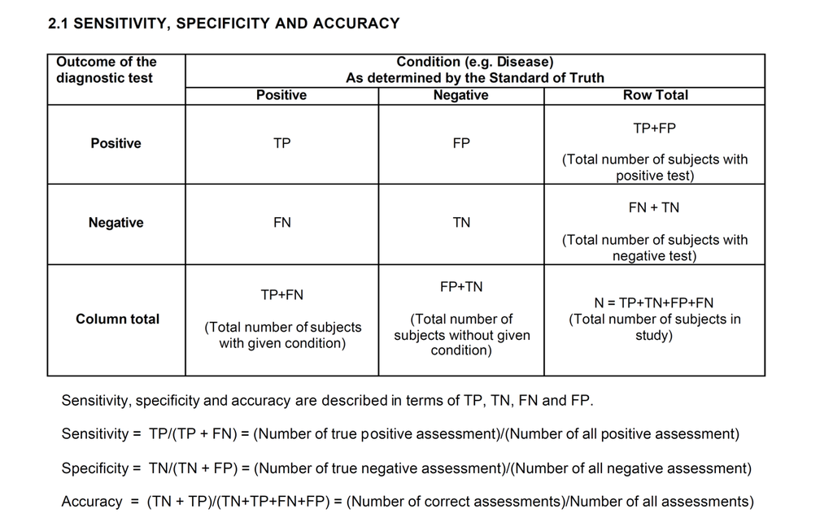

## 1.17 Error de predicció: Sensibilitat i especificitat

- Sensibilitat = P( Test + / malaltia )
- Especificitat = P (Test - / no malaltia )
- Precisió = P ( Test encerti ) (Probabilitat total d’encertar)

### 1.17.1 Sensibilitat i especificitat amb el model amb 5 predictors

```r
pre5 <- predict(pine_5,type='response')
ct<-0.5  # Valor per la probabilitat a partir del qual fem la predicció de mort
pre5[pre5>=ct] <- 1
pre5[pre5< ct] <- 0
(tablePred5 <- table(ex1DataPine$Y,pre5,dnn=c('Real','Predicció')))
```

```
##     Predicció
## Real  0  1
##    0 84  1
##    1  8 13
```

```r
sensi5 <- tablePred5[2,2]/sum(tablePred5[2,])
espec5 <- tablePred5[1,1]/sum(tablePred5[1,])
precis5 <- (tablePred5[1,1]+tablePred5[2,2])/sum(tablePred5)
(outp5 <- list(Sensblt=sensi5,Especft=espec5,Precis=precis5))
```

```
## $Sensblt
## [1] 0.6190476
##
## $Especft
## [1] 0.9882353
##
## $Precis
## [1] 0.9150943
```

#### 1.17.1.1 Què passa si modifiquem la probabilitat a partir de la qual fem la predicció de mort

```r
pre5 <- predict(pine_5,type='response')
ct<-0.242  # Valor per la probabilitat a partir del qual fem la predicció de mort
pre5[pre5>=ct] <- 1
pre5[pre5< ct] <- 0
(tablePred5 <- table(ex1DataPine$Y,pre5,dnn=c('Real','Predicció')))
```

```
##     Predicció
## Real  0  1
##    0 74 11
##    1  3 18
```

```r
sensi5 <- tablePred5[2,2]/sum(tablePred5[2,])
espec5 <- tablePred5[1,1]/sum(tablePred5[1,])
precis5 <- (tablePred5[1,1]+tablePred5[2,2])/sum(tablePred5)
(outp5 <- list(Sensblt=sensi5,Especft=espec5,Precis=precis5))
```

```
## $Sensblt
## [1] 0.8571429
##
## $Especft
## [1] 0.8705882
##
## $Precis
## [1] 0.8679245
```

## 1.18 Anàlisi de les corbes ROC (Receiver Operating Characteristics)

Per a una determinada prova diagnòstica, totes les combinacions de sensibilitat i (1 - especificitat) formen un espai ROC. A l’eix vertical indiquem la sensibilitat i al l’eix horitzontal (1-especificitat)

Una sensibilitat i especificitat concreta determinen un únic punt en l’espai ROC, i les posicions dels punts a l’espai ROC mostren l’equilibri entre sensibilitat i especificitat, és a dir, l’augment de la sensibilitat s’acompanya d’una disminució de l’especificitat. Així, la ubicació del punt en l’espai ROC mostra si la classificació d’una prova diagnòstica és bona o no. En una situació ideal, un punt estaria sobre la coordenada (0, 1). Aquest punt indicaria que la prova diagnòstica té una sensibilitat del 100% i una especificitat del 100%. Seria una classificació perfecta.

Un sol punt de tall d’una prova diagnòstica ens defineix un únic punt a l’espai ROC, però, diferents punts de tall possibles d’una prova diagnòstica determinen una corba a l’espai ROC, que rep el nom de corba ROC.

## 1.19 Exemple de corba ROC

| Punt de tall % | 1-Especificitat | Sensibilitat |
| --- | --- | --- |
| 20 | 0.85 | 0.93 |
| 25 | 0.34 | 0.73 |
| 30 | 0.20 | 0.67 |
| 50 | 0.12 | 0.60 |
| 70 | 0.10 | 0.30 |
| 80 | 0.05 | 0.11 |

La interpretació de la corba ROC és similar a la d’un sol punt en l’espai de la corba. Com més a prop del punt ideal estigui la corba ROC millor serà la prova diagnòstica. Com més a prop de la diagonal menys precisa.

Com més ràpidament s’apropi la corba al punt (0,1) millor seran els resultats.

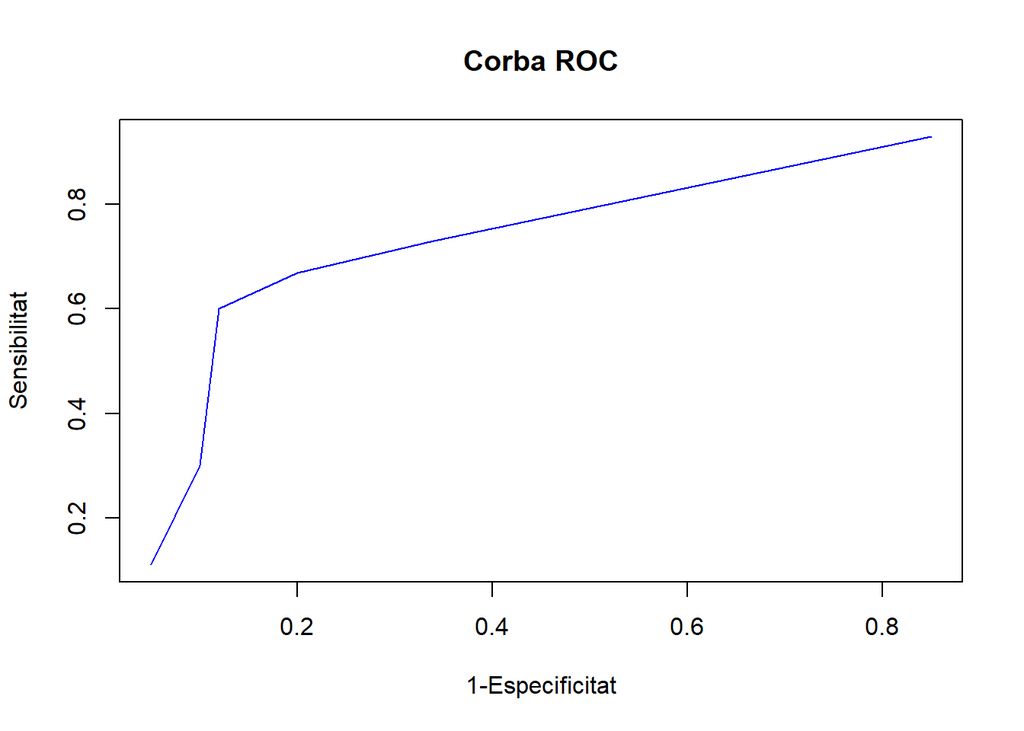

```r
plot(espec,sensi,type='l',col='blue',xlab=colnames(rocd)[2],ylab=colnames(rocd)[3],main='Corba ROC')
```

## 1.20 AUC

L’àrea sota la corba ROC (AUC) proporciona una manera de mesurar la precisió d’un test de diagnòstic. Com més gran sigui l’àrea més precís el test. L’AUC d’una corba ROC pot ser calculada a partir de l’equació següent

$$AUC = \int_0^1 ROC(t) dt$$
on t = (1 – especificitat) i ROC (t) és la sensibilitat.

Una classificació que es fa servir per classificar els tests segons l’AUC és la següent

| AUC Range | Classificació |
| --- | --- |
| 0.9 < AUC < 1.0 | Excel·lent |
| 0.8 < AUC < 0.9 | Bo |
| 0.7 < AUC < 0.8 | Regular |
| 0.6 < AUC < 0.7 | Dolent |

## 1.21 Exemple 1: Obtenció de la corba ROC i AUC

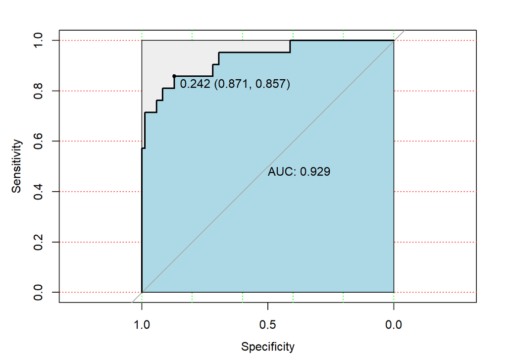

```r
library(pROC)
prob<-predict(pine_5,type='response')
g<-roc(ex1DataPine$Y,prob)
plot(g, print.auc=TRUE, auc.polygon=T, grid=c(0.2, 0.2),
     grid.col=c("green", "red"), max.auc.polygon=T,
     auc.polygon.col="lightblue", print.thres=TRUE)
```

```r
ci(g)
```

```
## 95% CI: 0.863-0.9958 (DeLong)
```

## 1.22 Models lineals mixtos generalitzats (GLMM)

Els models lineals mixtos generalitzats (GLMM) són una extensió natural dels models lineals generalitzats afegint efectes aleatoris al predictor lineal.

La funció d’enllaç $g(\cdot)$ és la mateixa que en els models lineals generalitzats.

El model lineal és

$$\eta_i = \textbf{X}_i \beta+
\textbf{Z}_i \textbf{u}_i + \textbf{e}_i$$

$$g(\mu_i) = E(\textbf{y}_i
|\textbf{u}_i)= \eta_i$$

$$\textbf{u}_i \sim
N(\textbf{0},\textbf{G})$$
- Assumim independència entre les $\textbf{e}_i$ i les $\textbf{u}_i$, i llavors

$$E(\textbf{y}_i |\textbf{u}_i)=
\mu_i$$

$$V(\textbf{y}_i |\textbf{u}_i)=\phi
v^{1/2}(\mu_{i}) \Lambda v^{1/2}(\mu_{i})$$

$\phi$ és un paràmetre de dispersió.

$$v^{1/2}(\mu_{i}) = diag
[\sqrt{v(\mu_{ij})}]$$
i la forma concreta de $v(·)$ depen de la familia de distribucions a la que pertany $Y$.

El model s’ajusta per ML si la variable pertany a la família exponencial o per quasi-likelihood si no és així. Generalment han de fer-se servir diverses aproximacions numèriques per maximitzar la versemblança.

## 1.23 Exemple sobre dades simulades

La funció **simul_glmm** ens permet simular un conjunt de dades format per individus classificats segons els nivells d’una variable tractament i que són seguits al llarg de diversos períodes de temps enregistrant si s’ha produït o no un determinat esdeveniment.

```r
simul_glmm<-function(ptrat,ptemps,nrep,inter=F,sd=0.01,seed=1234,interfect=1.2){
  set.seed(seed)
  ntrat<-length(ptrat)
  ntemps<-length(ptemps)
  nind<-nrep*ntrat
  id<-rep(1:nind,each=ntemps)
  treatment<-rep(1:ntrat,each=nrep*ntemps)
  period<-rep(1:ntemps,nind)
  p_event<-rep(ptrat,each=nrep*ntemps)+rep(ptemps,nind)
  if (inter){
    interac<-interaction(treatment,period)
    nivells<-sample(levels(interac),nlevels(interac)/4)
    p_event[interac %in% nivells]<- p_event[interac %in% nivells]*interfect
  }
  p_event<-p_event+rnorm(length(p_event),0,sd)
  p_event<-ifelse(p_event<0,0,p_event)
  p_event<-ifelse(p_event>1,1,p_event)
  event<-rbinom(nind*ntemps,1,p_event)
  data<-data.frame(id,treatment,period,event,p_event)
  data$treatment<-factor(data$treatment)
  data$period<-factor(data$period)
  return(data)
}
```

L’usuari pot dir el número de nivells del tractament, el número de períodes de temps, el número de rèpliques (individus) per cada nivell del tractament i quin són els efectes en termes de probabilitat: basal, del periode, del tractament i de la interacció.

Fem una primera simulació amb 100 individus per cadascú de 3 tractaments mesurats en 5 períodes de temps i sense interacció.

```r
ptrat<-c(0.1,0.3,0.4)
ptemps<-c(0,0,0.1,0.2,0.4)
nrep<-100
data1<-simul_glmm(ptrat,ptemps,nrep,inter=F,seed=1234)
head(data1)
```

| id | treatment | period | event | p_event |
| --- | --- | --- | --- | --- |
| 1 | 1 | 1 | 1 | 0.0879293 |
| 1 | 1 | 2 | 0 | 0.1027743 |
| 1 | 1 | 3 | 0 | 0.2108444 |
| 1 | 1 | 4 | 0 | 0.2765430 |
| 1 | 1 | 5 | 1 | 0.5042912 |
| 2 | 1 | 1 | 0 | 0.1050606 |

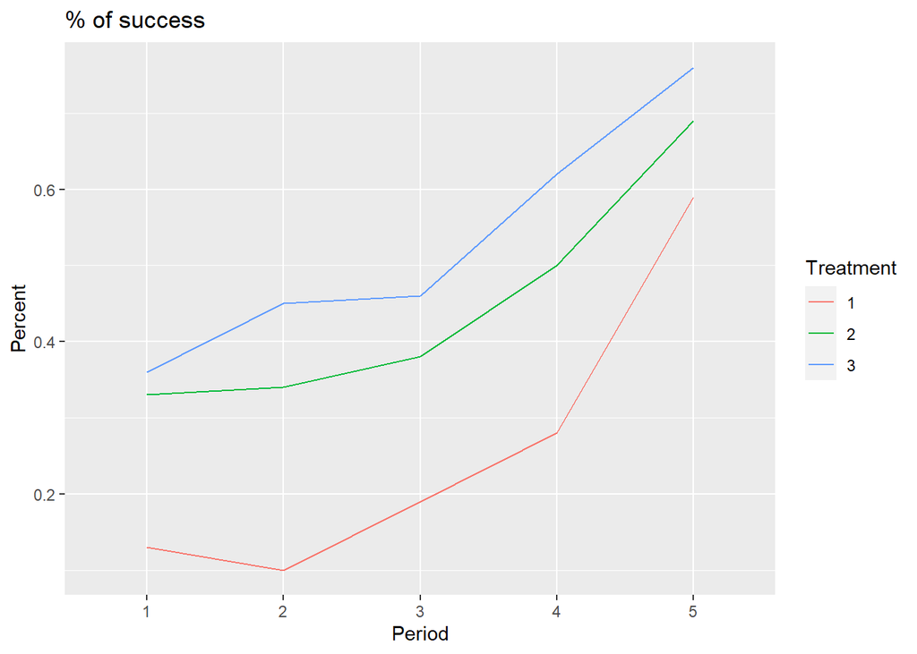

### 1.23.1 Ajust amb la funció **glmer** del package lme4

```r
library(lme4)
model1<-glmer(event~period*treatment+(1|id),data=data1,family=binomial)
summary(model1)
```

```
## Generalized linear mixed model fit by maximum likelihood (Laplace
##   Approximation) [glmerMod]
##  Family: binomial  ( logit )
## Formula: event ~ period * treatment + (1 | id)
##    Data: data1
##
##      AIC      BIC   logLik deviance df.resid
##   1825.1   1910.1   -896.6   1793.1     1484
##
## Scaled residuals:
##     Min      1Q  Median      3Q     Max
## -1.7824 -0.7501 -0.3863  0.8338  3.0021
##
## Random effects:
##  Groups Name        Variance Std.Dev.
##  id     (Intercept) 0.001958 0.04425
## Number of obs: 1500, groups:  id, 300
##
## Fixed effects:
##                    Estimate Std. Error z value Pr(>|z|)
## (Intercept)        -1.90160    0.29911  -6.358 2.05e-10 ***
## period2            -0.29643    0.44694  -0.663 0.507177
## period3             0.45104    0.39193   1.151 0.249803
## period4             0.95667    0.37192   2.572 0.010104 *
## period5             2.26572    0.36240   6.252 4.05e-10 ***
## treatment2          1.19311    0.36619   3.258 0.001121 **
## treatment3          1.32593    0.36387   3.644 0.000269 ***
## period2:treatment2  0.34131    0.53815   0.634 0.525935
## period3:treatment2 -0.23232    0.49123  -0.473 0.636260
## period4:treatment2 -0.24814    0.47270  -0.525 0.599623
## period5:treatment2 -0.75676    0.47119  -1.606 0.108264
## period2:treatment3  0.67128    0.53270   1.260 0.207618
## period3:treatment3 -0.03577    0.48723  -0.073 0.941482
## period4:treatment3  0.10878    0.47351   0.230 0.818311
## period5:treatment3 -0.53681    0.47782  -1.123 0.261246
## ---
## Signif. codes:  0 '***' 0.001 '**' 0.01 '*' 0.05 '.' 0.1 ' ' 1
```

```
##
## Correlation matrix not shown by default, as p = 15 > 12.
## Use print(x, correlation=TRUE)  or
##     vcov(x)        if you need it
```

```r
car::Anova(model1,type=3)
```

|  | Chisq | Df | Pr(>Chisq) |
| --- | --- | --- | --- |
| (Intercept) | 40.419268 | 1 | 0.0000000 |
| period | 68.486020 | 4 | 0.0000000 |
| treatment | 14.511818 | 2 | 0.0007060 |
| period:treatment | 8.176883 | 8 | 0.4163853 |

#### 1.23.1.1 Predicted versus theoretical probabilities

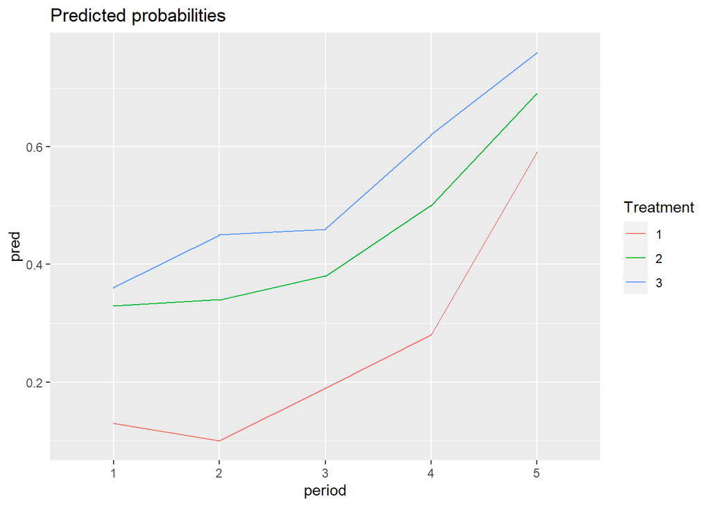

```r
data1$pred<-predict(model1,type='response')

ggplot(data1)+geom_line(aes(x=period,y=pred,group=treatment,col=as.factor(treatment)))+
  labs(title='Predicted probabilities',col='Treatment')
```

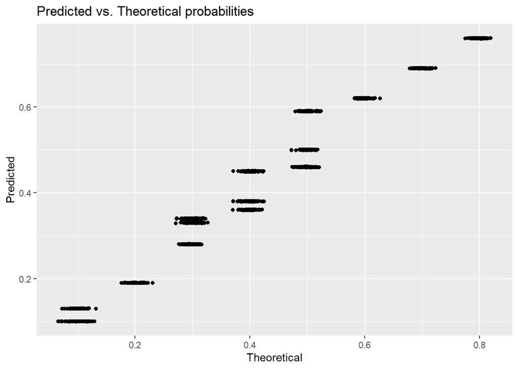

```r
ggplot(data1,aes(x=p_event,y=pred))+geom_point()+geom_jitter()+labs(title='Predicted vs. Theoretical probabilities',x='Theoretical',y='Predicted')
```

### 1.23.2 Ajust amb la funció **glmmPQL** del package MASS

La funció **glmmPQL** del package MASS permet introduir estructures de correlació. Aquesta funció es basa en la funció **lme** del package nlme. Les dues funcions proporcionen resultats idèntics sota la suposició de no correlació.

```r
library(MASS)
library(nlme)
model2<-glmer(event~period+treatment+(1|id),data=data1,family=binomial)
```

```
## boundary (singular) fit: see help('isSingular')
```

```r
model3<-glmmPQL(event~period+treatment,random=~1|id,data=data1,family=binomial,correlation=NULL)
```

```
## iteration 1
```

```
## iteration 2
```

```r
model2
```

```
## Generalized linear mixed model fit by maximum likelihood (Laplace
##   Approximation) [glmerMod]
##  Family: binomial  ( logit )
## Formula: event ~ period + treatment + (1 | id)
##    Data: data1
##       AIC       BIC    logLik  deviance  df.resid
## 1817.6969 1860.2026 -900.8484 1801.6969      1492
## Random effects:
##  Groups Name        Std.Dev.
##  id     (Intercept) 2.074e-06
## Number of obs: 1500, groups:  id, 300
## Fixed Effects:
## (Intercept)      period2      period3      period4      period5   treatment2
##     -1.8008       0.1207       0.3480       0.8983       1.8531       0.9458
##  treatment3
##      1.3107
## optimizer (Nelder_Mead) convergence code: 0 (OK) ; 0 optimizer warnings; 1 lme4 warnings
```

```r
model3
```

```
## Linear mixed-effects model fit by maximum likelihood
##   Data: data1
##   Log-likelihood: NA
##   Fixed: event ~ period + treatment
## (Intercept)     period2     period3     period4     period5  treatment2
##  -1.8008288   0.1206825   0.3480138   0.8982987   1.8531229   0.9457861
##  treatment3
##   1.3107323
##
## Random effects:
##  Formula: ~1 | id
##         (Intercept)  Residual
## StdDev:  0.07070769 0.9965896
##
## Variance function:
##  Structure: fixed weights
##  Formula: ~invwt
## Number of Observations: 1500
## Number of Groups: 300
```

Però **glmmPQL** ens permet introduir unes estructures de correlació diferents, per exemple

```r
model4<-glmmPQL(event~period+treatment,random=~1|id,data=data1,family=binomial,correlation=corAR1())
```

```
## iteration 1
```

```
## iteration 2
```

```
## iteration 3
```

```
## iteration 4
```

```r
model4
```

```
## Linear mixed-effects model fit by maximum likelihood
##   Data: data1
##   Log-likelihood: NA
##   Fixed: event ~ period + treatment
## (Intercept)     period2     period3     period4     period5  treatment2
##  -1.8023357   0.1206899   0.3481167   0.8983027   1.8537232   0.9471697
##  treatment3
##   1.3126579
##
## Random effects:
##  Formula: ~1 | id
##         (Intercept)  Residual
## StdDev:   0.1862584 0.9912782
##
## Correlation Structure: AR(1)
##  Formula: ~1 | id
##  Parameter estimate(s):
##         Phi
## -0.01292104
## Variance function:
##  Structure: fixed weights
##  Formula: ~invwt
## Number of Observations: 1500
## Number of Groups: 300
```